# Preprocessing using FinancialModelingR

# Introduction

`FinancialModelingR` package contains several data sets corresponding to commodities, especially soybeans. The following preprocessed data sets are already included:

- Soybean crop progress
- Soybean weekly exports
- Soybean WASDE reports

This notebook discusses how `FinancialModelingR` can be used to preprocess raw input files for the following types of data sets:

- Soybean crop progress
- Soybean weekly exports
- Soybean WASDE reports
- Commodity price
- Twitter API output

# Commodity Futures Price

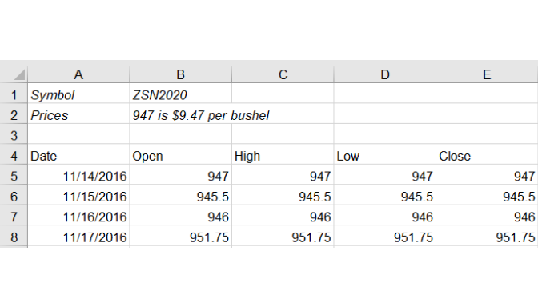

```r
library(FinancialModelingR)
library(png)
library(grid)
img <- readPNG("private_data/july2020.PNG")
grid.raster(img)
```

This module can be used to read contracts price from a given xlsx file that contains daily open, close, low and high prices of contracts. This data is private and has not been included in the package. The structure of the file is as shown above. The function `read_price` can be used to read the file and create columns with change in price. It can also be used to subset the price data by start date and to rename the price columns by appending a given prefix.

```r
contractsForJuly2020 <- FinancialModelingR::read_price(
  in_file = "private_data/ActiveSoybeanContractsforJuly2020.xlsx", delta_price = T,
  add_delta = T, subset = T, subset_min_date = "2017-01-01",
  rename_price_columns = T, rename_prefix = "july_2020_", skip_lines = 3)
contractsForJuly2020$Date <- as.Date(contractsForJuly2020$Date, "%Y-%m-%d")
saveRDS(contractsForJuly2020, "preprocessed_data/contractsForJuly2020.Rds")
```

# Tweets

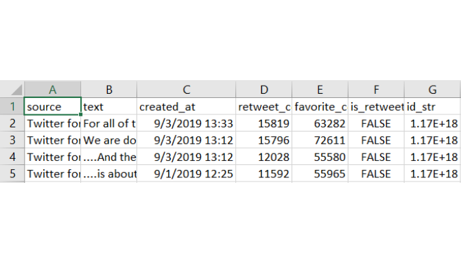

```r
img <- readPNG("private_data/tweets.PNG")
grid.raster(img)
```

This section uses document term matrix (DTM) created from Excel file containing tweets. Structure of the raw input file is shown above. The DTM is aggregated in daily level.

## Preprocessing Raw Tweets Data

### Exploration Type: Wordcloud

```r
library(data.table)
library(tm)
library(plyr)
library(dplyr)
library(qdap)

wd <- getwd()
setwd("raw_data/Tweets/")
tweet_files <- list.files(pattern = "\\.csv$")
for(file in tweet_files) {
  for(processed in c("unprocessed")) {
    process_text(file = file, processed = processed)
  }
}
setwd(wd)
```

### Document-Term-Matrix

```r
tweet_df <- data.frame(fread("raw_data/Tweets/China tweets @realDonaldTrump.csv"))
df1 <- data.frame(fread("raw_data/Tweets/FarmerTweets @realDonaldTrump.csv"))
tweet_df <- rbind(tweet_df, df1)
df1 <-  data.frame(fread("raw_data/Tweets/soybeans tweets @realDonaldTrump.csv"))
tweet_df <- rbind(tweet_df, df1)
dtm <- get_dtm(text = tweet_df$text, thr = 50)
tweet_df <- cbind(data.frame(created_at = tweet_df$created_at), dtm)
tweet_df$created_at <- as.Date(tweet_df$created_at, format = "%m-%d-%Y")
tweet_df <- tweet_df[!is.na(tweet_df$created_at), ]
tweet_df <- tweet_df %>% group_by(created_at) %>% summarize_all(sum)
```

## Using Cached Preprocessed Tweets Data

```r
tweet_df <- readRDS("private_data/text_features.Rds")
colnames(tweet_df)[1] <- "Date"
sds <- sapply(tweet_df[, 2:ncol(tweet_df)], sd)
remove_cols <- 1 + which(sds == 0)
if(length(remove_cols) > 0) {
  tweet_df <- tweet_df[, -remove_cols]
}
saveRDS(tweet_df, "preprocessed_data/tweet_df.Rds")
```

# Export Sales Report

## Raw Exports Data

Structure of a typical raw export sales report is shown below:

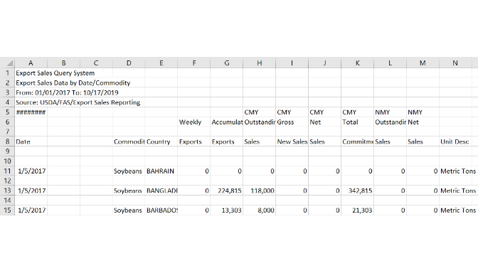

```r
library(png)
library(grid)
img <- readPNG("private_data/exports.PNG")
grid.raster(img)
```

## Preprocessing Raw Exports Data

```r
library(janitor)
soybeanExports = read_exports(
  file = "raw_data/ExportSalesDataByCommodity(Soybeans).csv", skip_lines = 4)
```

## From `FinancialModelingR`

```r
library(dplyr)
data("soybeanExports", package = "FinancialModelingR")
competitors <- c("ARGENTINA", "BRAZIL")
df_total_export <- soybeanExports %>% group_by(Country) %>%
  summarize(Total_Export = sum(Weekly_Exports, na.rm = T))
top_countries <- head(x = df_total_export$Country[
  order(df_total_export$Total_Export, decreasing = TRUE)], n = 10)
selected_countries <- c(competitors, top_countries)
df_top_export <- soybeanExports[sapply(
  soybeanExports$Country, function(country) country %in% selected_countries), ]
saveRDS(df_top_export, "preprocessed_data/top_10_export_countries.Rds")
```

# Crop Progress

## Raw Crop Progress Data

Structure of a typical crop progress report is shown below:

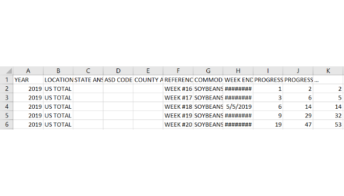

```r
img <- readPNG("private_data/crop_progress.PNG")
grid.raster(img)
```

## Preprocessing Raw Crop Progress Data

```r
soybeanCropProgress2019 <- read.csv("raw_data/ExportSalesDataByCommodity(Soybeans).csv")
soybeanCropProgress2019 <- soybeanCropProgress2019[, -c(2:5,7)]
```

## From `FinancialModelingR`

```r
data("soybeanCropProgressUSA2019", package = "FinancialModelingR")
soybeanCropProgress2019$WEEK.ENDING <-
  as.Date(soybeanCropProgress2019$WEEK.ENDING, "%Y-%m-%d")
saveRDS(soybeanCropProgress2019, "preprocessed_data/soybeanCropProgress2019.Rds")
```

# WASDE Report

## Raw WASDE Data

### Folder Structure

[figure not shown]

```r
img <- readPNG("private_data/wasde_folder.PNG")
grid.raster(img)
```

### File Structure

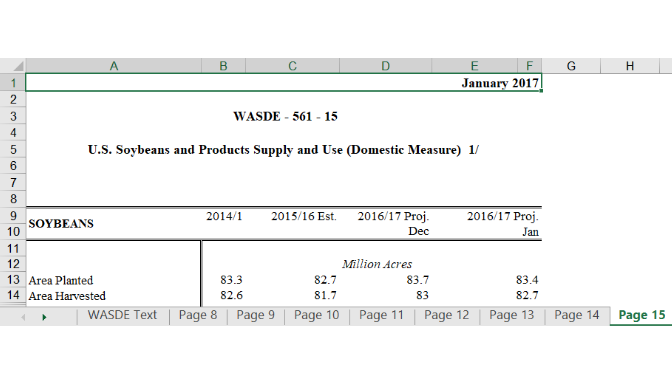

```r
img <- readPNG("private_data/wasde_file.PNG")
grid.raster(img)
```

## Preprocessing Raw WASDE Data

```r
library(readxl)
soybeanCombinedWASDE <- read_wasde(path = "raw_data/WASDE/")
```

## From `FinancialModelingR`

```r
data("soybeanCombinedWASDE")
soybeanWASDE_clean <- clean_wasde(combined_data = soybeanCombinedWASDE)
saveRDS(soybeanWASDE_clean, "preprocessed_data/soybeanWASDE_clean.Rds")
```